# Project 1

03/02/2021

**Title:** Briefing Memorandum

**To:** Dr. Random

**From:** Yiling Du, Alec Mattu, Delmar Randolph, Bryce Hawkins, Onyekachi Igwenagu

**Subject:** Analysis of 110 automotive vehicle models from 2015

## Background

The purpose of this analysis is to provide insights into 110 vehicle models available in 2015 from various manufacturers. Aside from providing evaluations of various aspects about this dataset, the goal is to locate trends common between different variables. Our dataset is sourced from www.lock5stat.com/datapage.html and includes a small proportion of all available makes and models from 2015. Although it was compiled by lock5stat.com, the original data was provided by KBB.com in 2015. Of the 110 models listed, 20 variables on each observation are available for interpretation.

#### Table of Variables

| Variable | Name | Example |
| --- | --- | --- |
| Make | Vehicle manufacturer | Toyota |
| Model | Vehicle model | Prius |
| Type | Vehicle category | Small, Hatchback, Sedan, Etc |
| LowPrice | Lowest MSRP Available (In 1000s) | 6.5 |
| HighPrice | Highest MSRP Available (In 1000s) | 9.5 |
| Drive | Vehicle output driveaxle | FWD |
| CityMPG | City miles per gallon avg | 36 |
| HwyMPG | Highway miles per gallon avg | 44 |
| FuelCap | Gas tank capacity in gallons | 12.5 |
| Length | Bumper-to-bumper vehicle length (Inch) | 178.5 |
| Width | Door-to-door vehicle width (Inch) | 69.2 |
| Height | Vehicle height from ground-to-roof (Inch) | 58.1 |
| Wheelbase | Vehicle wheelbase (Inch) | 106.5 |
| UTurn | Vehicle 180deg U-turn radius (Feet) | 16 |
| Weight | Vehicle dry weight (Lbs) | 2200 |
| Acc030 | Vehicle accel. to 30mph (Seconds) | 62 |
| Acc060 | Vehicle accel. to 60mph (Seconds) | 190 |
| QtrMile | Vehicle time in seconds to 1/4th mile | 92 |
| PageNum | Reference page number in the ConsumerReports mag. | 13 |
| Size | Vehicle size (Small, Midsized, Large) | Large |

## Data Analyses

### Analysis 1: One Quantitative Variable

#### Analyst: Yiling Du

```r
cars <- read.csv(file.choose(), header=T)
cars
```

```
##          Make       Model      Type LowPrice HighPrice Drive CityMPG HwyMPG FuelCap Length Width
## 1   Chevrolet       Spark Hatchback   12.270    25.560   FWD      30     39     9.0    145    63
## 2     Hyundai      Accent Hatchback   14.745    17.495   FWD      28     37    11.4    172    67
## 3         Kia         Rio     Sedan   13.990    18.290   FWD      28     36    11.3    172    68
## 4  Mitsubishi      Mirage Hatchback   12.995    15.395   FWD      37     44     9.2    149    66
## 5      Nissan  Versa Note Hatchback   14.180    17.960   FWD      31     40    10.9    164    67
## 6       Dodge        Dart     Sedan   16.495    23.795   FWD      23     35    14.2    184    72
## 7  Chevrolet     Cruze LS     Sedan   16.170    25.660   FWD      24     36    15.6    181    71
## 8        Fiat        500L Hatchback   19.345    24.695   FWD      24     33    13.1    167    70
## 9        Ford       Focus Hatchback   17.170    29.170   FWD      28     38    12.4    179    72
## 10     Toyoto       Yaris Hatchback   14.845    17.629   FWD      30     35    11.1    154    67
## 11      Mazda   2 Touring Hatchback   14.720    17.050   FWD      27     33    11.3    156    68
## 12     Subaru     Impreza     Sedan   18.195    23.295   AWD      27     36    14.5    180    69
## 13 Volkswagon       Jetta     Sedan   16.215    31.120   FWD      25     36    14.5    182    70
## 14      Ford       Fiesta Hatchback   14.455    21.435   FWD      27     37    12.4    174    68
```

[output cut: 88 more lines]

analyze the Quantitative Variable “CityMPG” (City miles per gallon), get the five number summary, mean, standard deviation, and variance.

```r
summary(cars$CityMPG)
```

```
##    Min. 1st Qu.  Median    Mean 3rd Qu.    Max.
##   12.00   17.00   20.00   20.78   24.00   37.00
```

```r
sd(cars$CityMPG)
```

```
## [1] 4.546158
```

```r
var(cars$CityMPG)
```

```
## [1] 20.66756
```

draw histogram and box plot for CityMPG

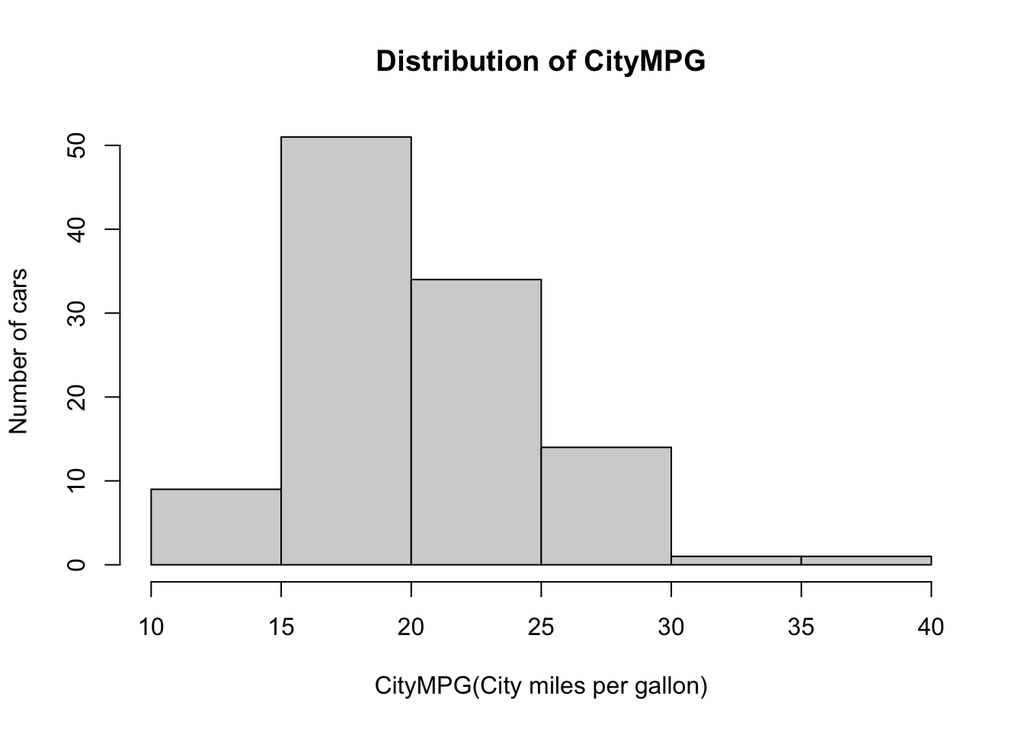

```r
hist(cars$CityMPG, breaks=5,
     main = "Distribution of CityMPG",
     xlab= "CityMPG(City miles per gallon)",
     ylab= "Number of cars")
```

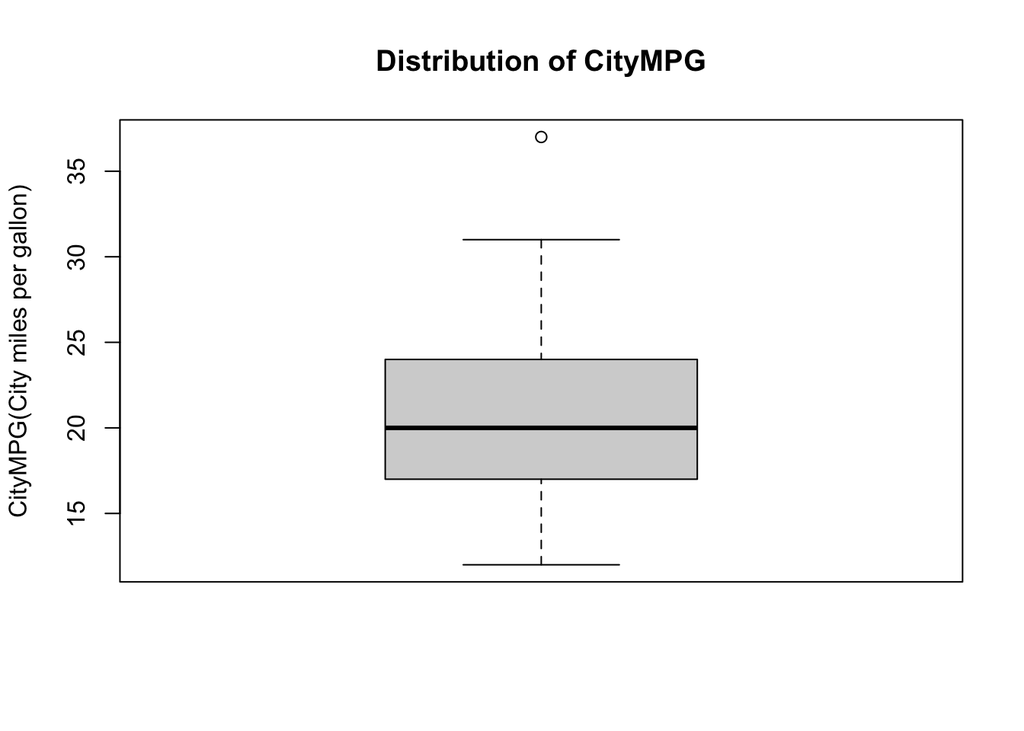

```r
boxplot(cars$CityMPG,
        main = "Distribution of CityMPG",
        ylab= "CityMPG(City miles per gallon)")
```

Analysis 1 Discussion: From the five number summary, and the mean, we can know median < mean, so the distribution is right-skewed. We also can see right-skewed from the histogram easily. We can see there is one prominent peak in the histogram, so it is unimodal. From the box plot, we can see there is an outlier. Median and IQR are more robust to skewness than mean and s.d, so in this case, it is more helpful to use median and IQR. The median/center is 20, it means 55 cars’ City miles per gallon is less than 20, and 55 cars’s City miles per gallon is more than 20. IQR is good to describe the spread of the database. IQR=Q3-Q1=7, it means the range of the middle 50% of the data span is 7.

### Analysis 2: One Categorical Variable

#### Analyst: Alec Mattu

Lets begin the interpretation by loading the Cars2015.csv file into an accessible variable names cars. After we read the dataset into our environment, we just verify that the data did successfully load by typing `cars` into the console.

```r
cars <- read.csv(file.choose(), header=T)
cars
```

```
##          Make       Model      Type LowPrice HighPrice Drive CityMPG HwyMPG FuelCap Length Width
## 1   Chevrolet       Spark Hatchback   12.270    25.560   FWD      30     39     9.0    145    63
## 2     Hyundai      Accent Hatchback   14.745    17.495   FWD      28     37    11.4    172    67
## 3         Kia         Rio     Sedan   13.990    18.290   FWD      28     36    11.3    172    68
## 4  Mitsubishi      Mirage Hatchback   12.995    15.395   FWD      37     44     9.2    149    66
## 5      Nissan  Versa Note Hatchback   14.180    17.960   FWD      31     40    10.9    164    67
## 6       Dodge        Dart     Sedan   16.495    23.795   FWD      23     35    14.2    184    72
## 7  Chevrolet     Cruze LS     Sedan   16.170    25.660   FWD      24     36    15.6    181    71
## 8        Fiat        500L Hatchback   19.345    24.695   FWD      24     33    13.1    167    70
## 9        Ford       Focus Hatchback   17.170    29.170   FWD      28     38    12.4    179    72
## 10     Toyoto       Yaris Hatchback   14.845    17.629   FWD      30     35    11.1    154    67
## 11      Mazda   2 Touring Hatchback   14.720    17.050   FWD      27     33    11.3    156    68
## 12     Subaru     Impreza     Sedan   18.195    23.295   AWD      27     36    14.5    180    69
## 13 Volkswagon       Jetta     Sedan   16.215    31.120   FWD      25     36    14.5    182    70
## 14      Ford       Fiesta Hatchback   14.455    21.435   FWD      27     37    12.4    174    68
```

[output cut: 88 more lines]

For this analysis of a single categorical variable, I’ve chosen to breakdown the vehicle type category. Although I could have picked another categorical variable, such as Size (Sm/Md/Lg) or Drive (FWD/RWD/AWD), I figured it would be neat to take a look at a variable with so many options (Small, Hatchback, Sedan, etc).

Lets begin the core analysis by listing the frequency of the categories in the dataset.

```r
table(cars$Type)
```

```
##
##     7Pass Hatchback     Sedan    Sporty       SUV     Wagon
##        15        11        46        11        18         9
```

From the output generated above, we can see that there are 6 categories of vehicles: 7-Passenger, Hatchback, Sedan, Sporty, SUV, and Wagon. Of those categories, the distribution is as such: 7-Passenger (15), Hatchback (11), Sedan (46), Sporty (11), SUV (18), and Wagon (9).

Let’s take a look at a pie chart to visualize the outputs from the above table. First, we will make use of a library called Plyr, which allows us to count the frequency of each type and apply it to the `c()` function easily.

```r
library('plyr')
```

Then we will call the `count()` function, provided by Plyr.

```r
freq_table <- count(cars$Type)
freq_table
```

```
##           x freq
## 1     7Pass   15
## 2 Hatchback   11
## 3     Sedan   46
## 4    Sporty   11
## 5       SUV   18
## 6     Wagon    9
```

Now that this data is easily split up, we can apply it to the `c()` function and build a pie chart.

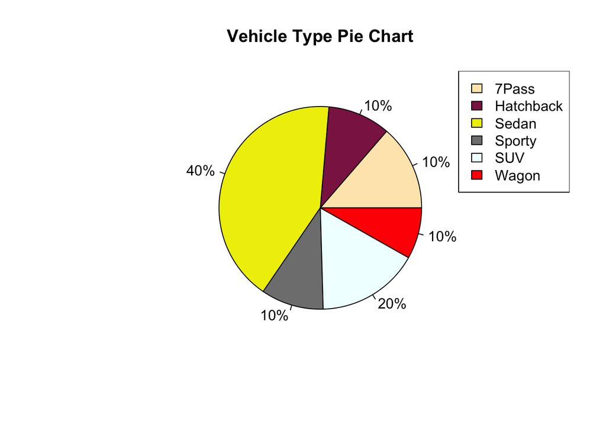

```r
label_colors <- c("wheat1", "violetred4", "yellow2", "grey50", "azure1", "red")
labels <- c(freq_table$x)
percentageLabels <- paste(round(freq_table$freq / 110, 1) * 100, "%", sep = "")
slices <- c(freq_table$freq)
pie(slices, labels = percentageLabels, main = "Vehicle Type Pie Chart", col = label_colors)
legend("topright", freq_table$x, fill = label_colors)
```

From this visualization above, we can easily see that the sedan class dominates the rest of the types. However, this IS a statistics class, so let’s get hardcore numbers.

In order to determine the proportion of vehicles in a specific category, we need to calculate the number of vehicles listed in the dataset. A simple call to `nrows()` will give us this number.

```r
number_of_rows <- nrow(cars)
number_of_rows
```

```
## [1] 110
```

This gives us 110 total rows, which we can verify by adding up the number of vehicles in each type category. Or, we can call `sum(slices)` to verify that every vehicle in the dataset has a type assigned.

```r
sum(slices) == number_of_rows
```

```
## [1] TRUE
```

Now that we’ve verified that the number of rows/observations equals the number of types counted, we can calculate concrete numbers.

The number of 7-Passenger vehicles in proportion to the 110 figure we found above:

```r
freq_table$freq[1] / number_of_rows
```

```
## [1] 0.1363636
```

This figure indicates that 7-pass vehicles represent ~13.6% of the vehicles apart of the dataset.

Next, we take a look at Hatchback vehicles:

```r
freq_table$freq[2] / number_of_rows
```

```
## [1] 0.1
```

Not far off of 7-passenger vehicles, we see that hatchbacks make up 10% of the vehicles in the dataset.

Moving onto sedans, we can anticipate ~40% of the vehicles are comprised of this vehicle type; Let’s find out for sure:

```r
freq_table$freq[3] / number_of_rows
```

```
## [1] 0.4181818
```

No surprise here, this was present visually in the graph already. Sedans make up nearly ~42% of the 110 vehicles in the dataset.

Next to the smaller group of vehicle types, we’re evaluating the “Sporty”, “SUV”, and “Wagon” types below.

As with the other types, take the sporty type and divide it by the sum of vehicle type observations.

```r
freq_table$freq[4] / number_of_rows
```

```
## [1] 0.1
```

No abnormalities here, the sporty type accounts for 10% of the vehicle dataset sample.

Moving on to the SUV type,

```r
freq_table$freq[5] / number_of_rows
```

```
## [1] 0.1636364
```

Although substantially under the Sedan type, the SUV comes in at just under 17% of the sample.

Last and it just so happens to be least, the Wagon type makes up a mere 8% of the vehicle types in the dataset. Not exactly a surprise, given the rarity of finding a wagon on the road today.

```r
freq_table$freq[6] / number_of_rows
```

```
## [1] 0.08181818
```

Now that we have seen a pie chart and actual representative numbers, let’s take a look at the histogram to solidify our analyis.

Let’s create the proper data frames to supply to the bar chart functions.

```r
type_df <- data.frame(x = freq_table$x, y = freq_table$freq)
type_df
```

```
##           x  y
## 1     7Pass 15
## 2 Hatchback 11
## 3     Sedan 46
## 4    Sporty 11
## 5       SUV 18
## 6     Wagon  9
```

Let’s generate the histogram to display the frequency of vehicles in a particular vehicle type category.

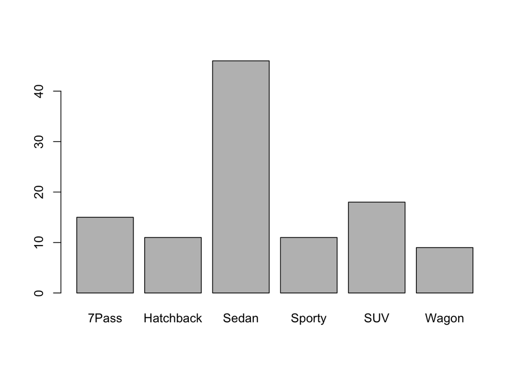

```r
barplot(type_df$y, names.arg = type_df$x)
```

Of course this graph is no different in utility from the pie chart, but it allows us to see the absolute values of the vehicle types represented in a visual manner. From this, again we can see that the sedan type outnumbers all of the other types, and SUV comes in second place by a very large margin. Based on information gathered from this dataset, it’s a safe assumption that passenger vehicles (sedans) make up a large proportion of vehicles on the road in The United States of America.

### Analysis 3: Two Categorical Variables

#### Analyst:Bryce Hawkins

# 1) Import the “Cars2015.csv” dataset, and assign it to the data “cars”.